# Introduction to R

William Surles

2017-03-28

> This document was updated on **2017-03-29**.

# Introduction

- I am copying my work from the class to this document
- This will make it much easier for me to find and refernce what I have done/learned
- Most of this is simply me copying the working solutions from the class examples or practice
- I may insert a few of my own thoughts and comments along the way
- This all comes from [Introduction to R](https://campus.datacamp.com/courses/free-introduction-to-r) course on DataCamp
  - I highly recommend the [DataCamp](https://www.datacamp.com/home) courses
  - They step you through the work and include videos and much more description than I include here
  - This doc is no replacement for working through the classes on your own!

# Intro to Basics

### How it Works

- This section has some pretty juicy R charts here.
- This was hott stuff back in 1996
  - Many of these styles of charts are still usefull now for data exploration
  - Thought I would not use base R graphics to make them
  - I’d start with ggplot2 or ggvis
  - Still its fun to see these charts. Don’t wory about the code to make them for now.

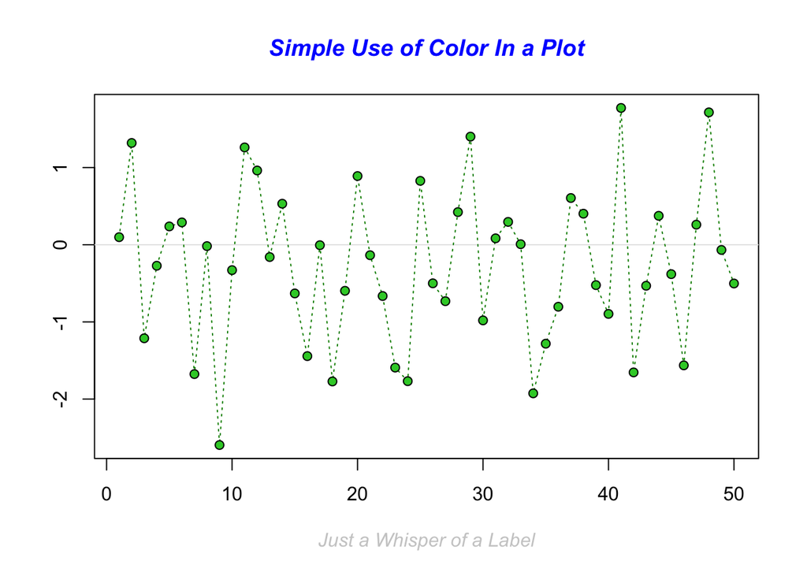

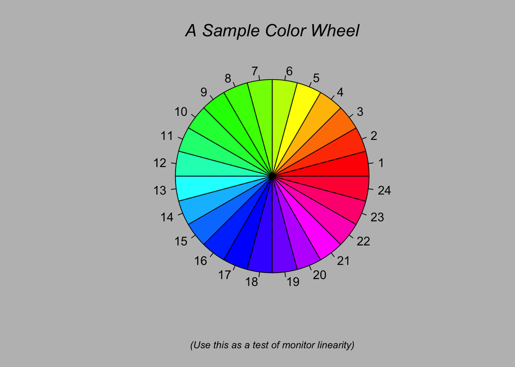

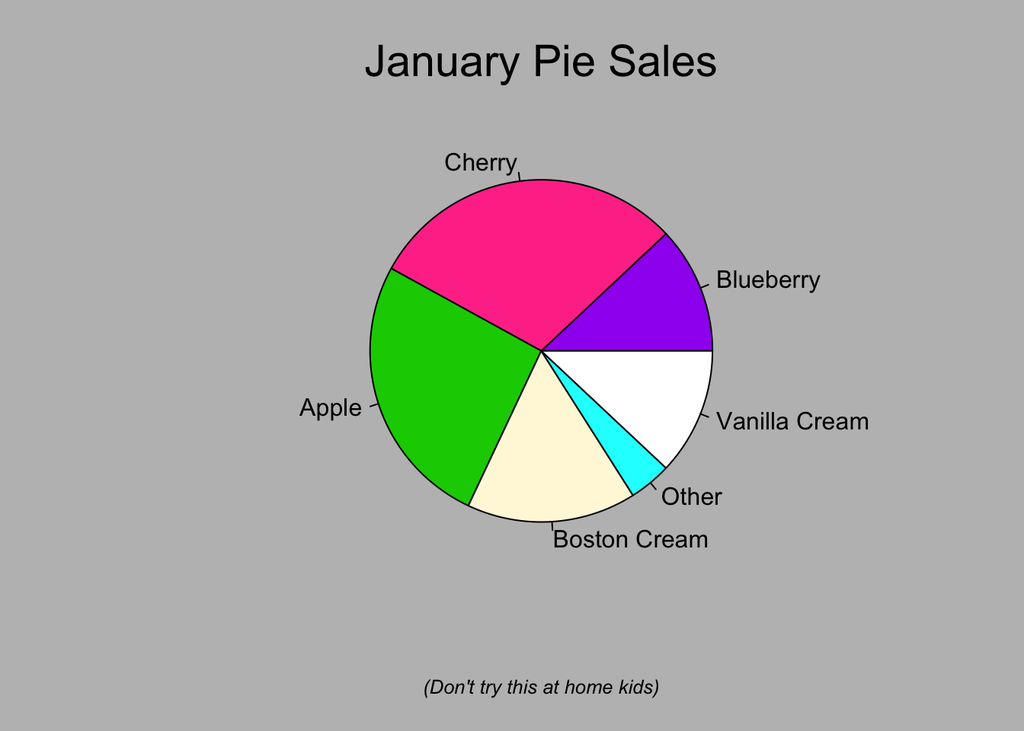

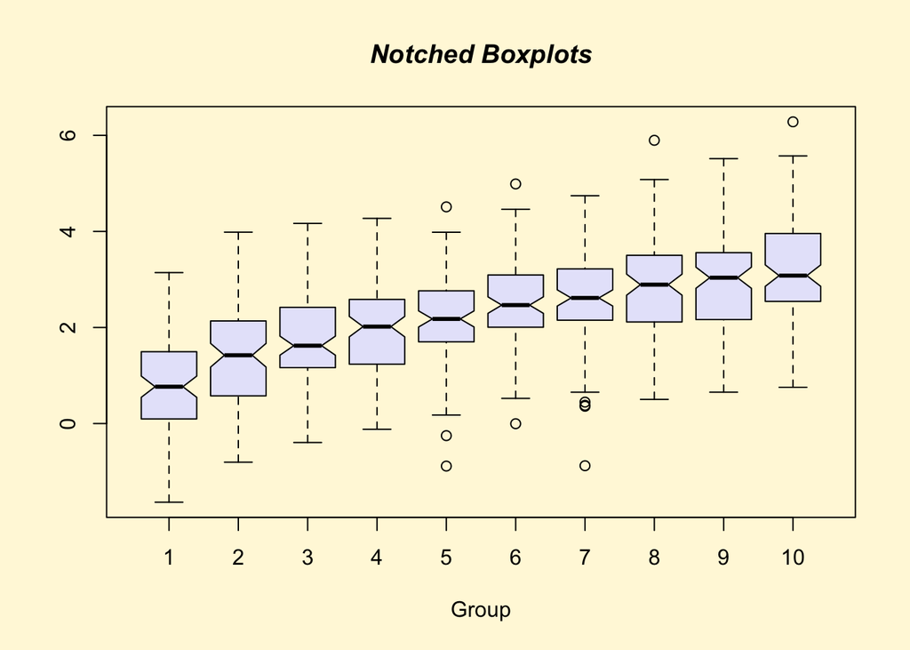

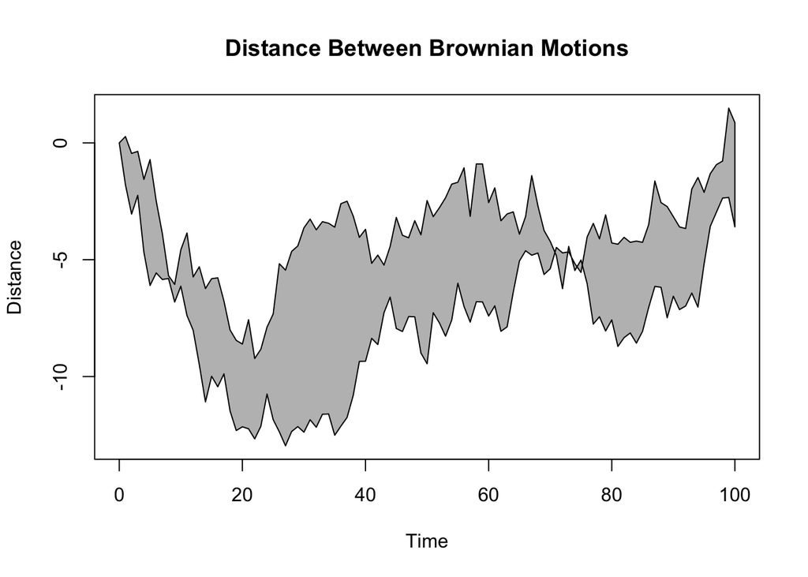

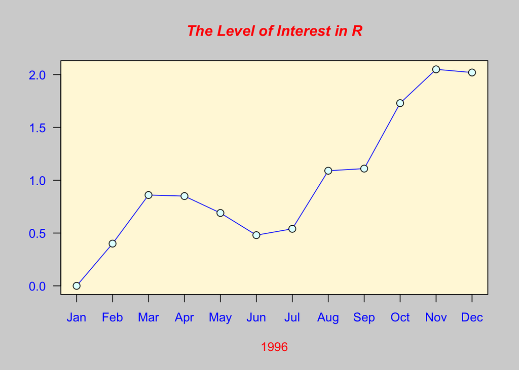

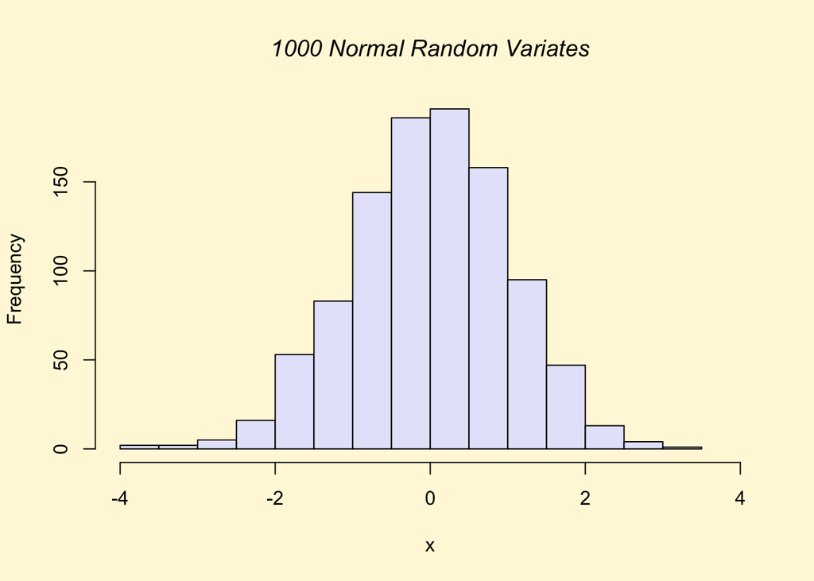

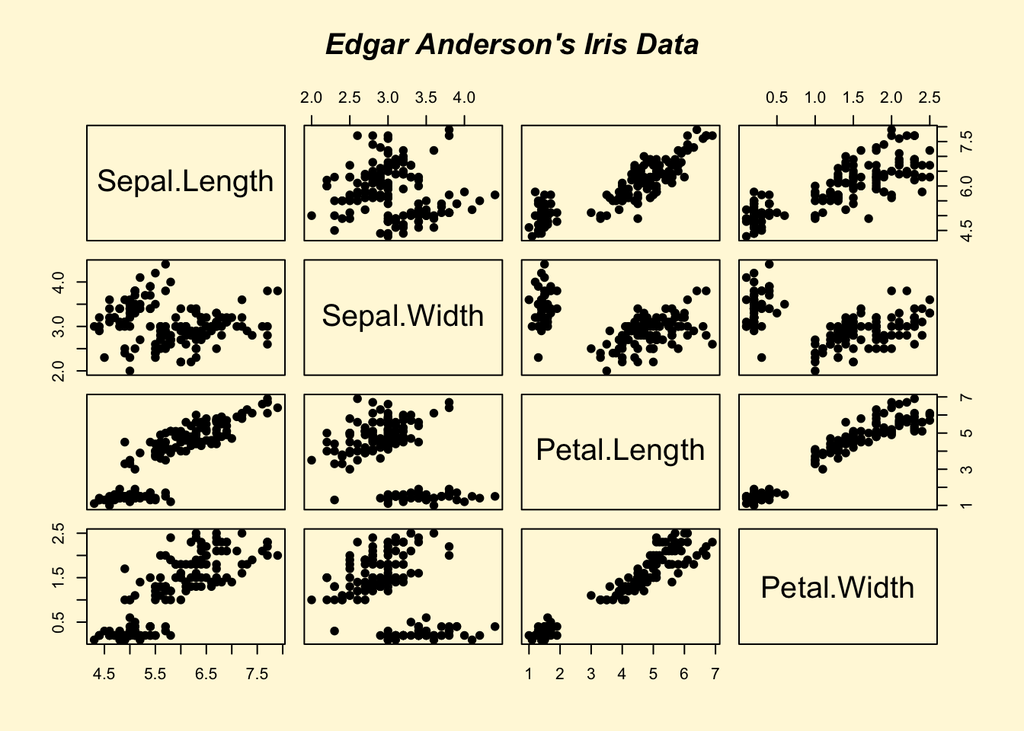

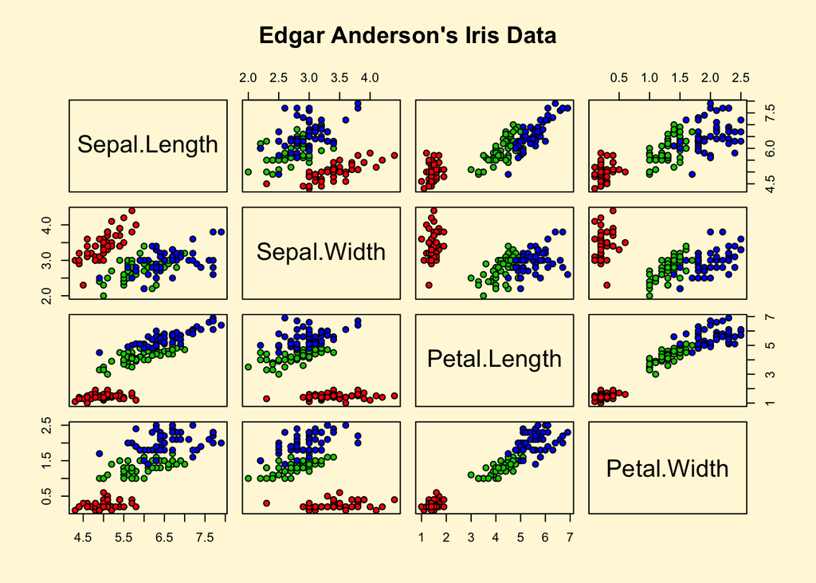

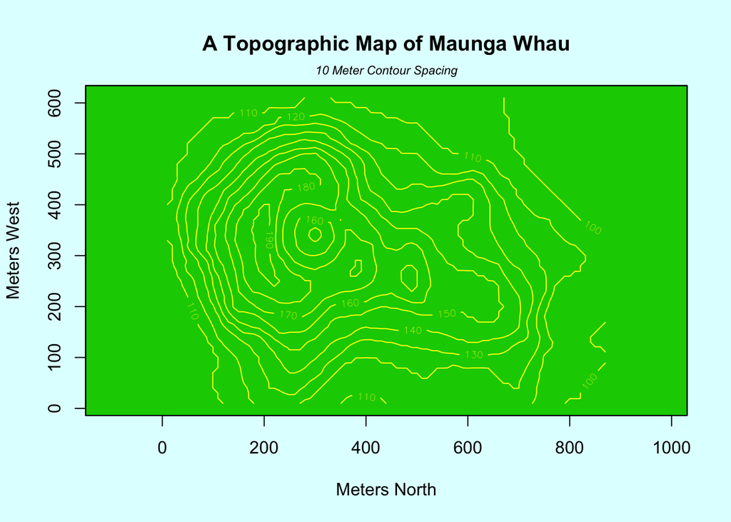

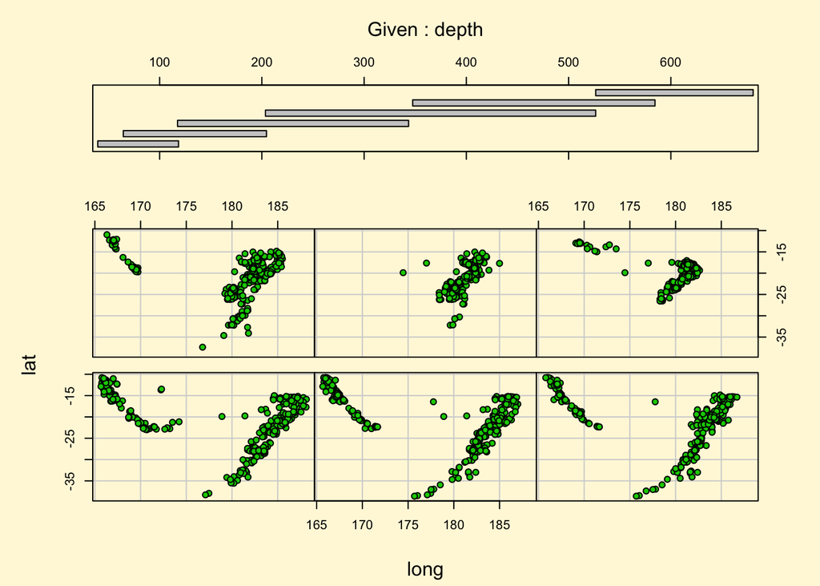

```r
# The hashtag is used to add comments

# Show some demo graphs generated with R
demo("graphics")
```

### Arthmetic with R

Yeah, it does all the usual stuff.

```r
# An addition
5 + 5
```

```
## [1] 10
```

```r
# A substraction
5 - 5
```

```
## [1] 0
```

```r
# A multiplication
3 * 5
```

```
## [1] 15
```

```r
# A division
(5 + 5)/2
```

```
## [1] 5
```

```r
# Exponentiation
2^5
```

```
## [1] 32
```

```r
# Modulo
17%%4
```

```
## [1] 1
```

### Variable assignment

```r
# Assign the value 42 to x
x <- 42

# Print out the value of the variable x
x
```

```
## [1] 42
```

### Variable assignment 2

```r
# Assign the value 5 to the variable called my_apples
my_apples <- 5
my_apples
```

```
## [1] 5
```

### Variable assignment 3

```r
# Assign a value to the variables called my_apples and my_oranges
my_apples <- 5
my_oranges <- 6

# Add these two variables together and print the result
my_fruit <- my_apples + my_oranges
my_fruit
```

```
## [1] 11
```

### Apples and oranges

- This would fail because you can’t add character vectors.
- Rstudio won’t even knit the document.
- It will throw an error in the code.
- I have `eval=F` so this will run and just paste the error below

```r
# Assign a value to the variable called my_apples
my_apples <- 'apples'
my_oranges <- 'oranges'

# Add a character
my_fruit <- my_apples + my_oranges
```

`Error in my_apples + my_oranges : non-numeric argument to binary operator`

### Basic data types in R

```r
# What's the answer to the universe
my_numeric <- 42

# The quotation marks indicate that the variable is of type character
my_character <- "forty-two"

my_logical <- FALSE
```

### Whats’s that data type?

```r
# Declare variables of different types
my_numeric <- 42
class(my_numeric)
```

```
## [1] "numeric"
```

```r
my_character <- "forty-two"
class(my_character)
```

```
## [1] "character"
```

```r
my_logical <- FALSE
class(my_logical)
```

```
## [1] "logical"
```

# Vectors

- Note: I almost **always** use dataframes
- But I guess its still good to know the other data types
- They all have there uses

### Create a vector

```r
Vegas <- as.character("Here we go!")
Vegas
```

```
## [1] "Here we go!"
```

### Create a vector (2)

```r
numeric_vector <- c(1, 10, 49)
character_vector <- c("a", "b", "c")
boolean_vector <- c(T,F,T)

# Print the vectors
numeric_vector
```

```
## [1]  1 10 49
```

```r
character_vector
```

```
## [1] "a" "b" "c"
```

```r
boolean_vector
```

```
## [1]  TRUE FALSE  TRUE
```

### Create a vector (3)

```r
# Poker winnings from Monday to Friday
poker_vector <- c(140, -50, 20, -120, 240)
poker_vector
```

```
## [1]  140  -50   20 -120  240
```

```r
# Roulette winnings form Monday to Friday
roulette_vector <- c(-24, -50, 100, -350, 10)
roulette_vector
```

```
## [1]  -24  -50  100 -350   10
```

### Naming a vector

```r
## Name the vectors
names(poker_vector) <- c("Mon","Tues","Wed","Thur","Fri")
poker_vector
```

```
##  Mon Tues  Wed Thur  Fri
##  140  -50   20 -120  240
```

```r
names(roulette_vector) <- c("Mon","Tues","Wed","Thur","Fri")
roulette_vector
```

```
##  Mon Tues  Wed Thur  Fri
##  -24  -50  100 -350   10
```

### Naming a vector (2)

```r
# Create the variable days_vector
days_vector <- c("Mon","Tues","Wed","Thur","Fri")

# Assign the names of the day to the roulette and poker_vectors
names(poker_vector) <- days_vector
poker_vector
```

```
##  Mon Tues  Wed Thur  Fri
##  140  -50   20 -120  240
```

```r
names(roulette_vector) <- days_vector
roulette_vector
```

```
##  Mon Tues  Wed Thur  Fri
##  -24  -50  100 -350   10
```

### Calculating total winnings

```r
## First, just an example
A_vector <- c(1, 2, 3)
B_vector <- c(4, 5, 6)

# Take the sum of A_vector and B_vector
total_vector <- A_vector + B_vector
total_vector
```

```
## [1] 5 7 9
```

### Calculating total winnings (2)

```r
# Name poker and roulette
days <- c("Monday", "Tuesday", "Wednesday", "Thursday", "Friday")
names(roulette_vector) <- days
names(poker_vector) <- days

total_daily <- poker_vector + roulette_vector
total_daily
```

```
##    Monday   Tuesday Wednesday  Thursday    Friday
##       116      -100       120      -470       250
```

### Calculating total winnings (3)

```r
total_poker <- sum(poker_vector)
total_roulette <- sum(roulette_vector)

total_week <- sum(roulette_vector) + sum(poker_vector)
total_week
```

```
## [1] -84
```

### Comparing total winnings

```r
# Check if you realized higher total gains in poker then in roulette
answer <- total_poker > total_roulette
answer
```

```
## [1] TRUE
```

### Vector selection: the good times

```r
# Define new variable based on a selection
poker_wednesday <- poker_vector["Wednesday"]
poker_wednesday
```

```
## Wednesday
##        20
```

### Vector selection: the good times (2)

```r
# Define new variable based on a selection
poker_midweek <- poker_vector[c("Tuesday","Wednesday","Thursday")]
poker_midweek
```

```
##   Tuesday Wednesday  Thursday
##       -50        20      -120
```

### Vector selection: the good times (3)

```r
# Define new variable based on a selection
roulette_selection_vector <- roulette_vector[2:5]
roulette_selection_vector
```

```
##   Tuesday Wednesday  Thursday    Friday
##       -50       100      -350        10
```

### Vector selection: the good times (4)

```r
average_midweek_gain <- mean(poker_vector[c("Monday","Tuesday","Wednesday")])
average_midweek_gain
```

```
## [1] 36.66667
```

### Selection by comparison - Step 1

```r
# What days of the week did you make money on poker
selection_vector <- poker_vector > 0
selection_vector
```

```
##    Monday   Tuesday Wednesday  Thursday    Friday
##      TRUE     FALSE      TRUE     FALSE      TRUE
```

### Selection by comparison - Step 2

```r
# What days of the week did you make money on poker
selection_vector <- poker_vector > 0

# Select from poker_vector these days
poker_winning_days <- poker_vector[selection_vector]
poker_winning_days
```

```
##    Monday Wednesday    Friday
##       140        20       240
```

### Advanced selection

```r
# Show me
roulette_winning_days <- roulette_vector[roulette_vector > 0]
roulette_winning_days
```

```
## Wednesday    Friday
##       100        10
```

# Matrices

### What’s a matrix?

```r
# Construction of a matrix with 3 rows containing the numbers 1 up to 9
matrix(1:9, byrow=T, nrow=3)
```

```
##      [,1] [,2] [,3]
## [1,]    1    2    3
## [2,]    4    5    6
## [3,]    7    8    9
```

### Analyzing matrices, you shall

```r
# Box office Star Wars: In Millions!
# The first element: US, the second element: Non-US
new_hope = c(460.998007, 314.4)
empire_strikes = c(290.475067, 247.900000)
return_jedi = c(309.306177,165.8)

# Add your code below to construct the matrix
star_wars_matrix = matrix(c(new_hope, empire_strikes, return_jedi), byrow=T, nrow=3)
star_wars_matrix
```

```
##          [,1]  [,2]
## [1,] 460.9980 314.4
## [2,] 290.4751 247.9
## [3,] 309.3062 165.8
```

### Naming a matrix

```r
# Add your code here such that rows and columns of star_wars_matrix have a
# name!
rownames(star_wars_matrix) = c('A New Hope','The Empire Strikes Back','Return of the Jedi')
colnames(star_wars_matrix) = c('US','non-US')
star_wars_matrix
```

```
##                               US non-US
## A New Hope              460.9980  314.4
## The Empire Strikes Back 290.4751  247.9
## Return of the Jedi      309.3062  165.8
```

### Calculating the worldwide box office

```r
# Box office Star Wars: In Millions (!)
# Construct matrix:
box_office_all = c(461, 314.4,290.5, 247.9,309.3,165.8)
movie_names = c("A New Hope","The Empire Strikes Back","Return of the Jedi")
col_titles = c("US","non-US")

star_wars_matrix = matrix(box_office_all, nrow=3, byrow=TRUE, dimnames=list(movie_names,col_titles))
star_wars_matrix
```

```
##                            US non-US
## A New Hope              461.0  314.4
## The Empire Strikes Back 290.5  247.9
## Return of the Jedi      309.3  165.8
```

```r
worldwide_vector = rowSums(star_wars_matrix)
worldwide_vector
```

```
##              A New Hope The Empire Strikes Back      Return of the Jedi
##                   775.4                   538.4                   475.1
```

### Adding a column for the worldwide box office

```r
# Bind the new variable worldwide_vector as a column to star_wars_matrix
all_wars_matrix = cbind(star_wars_matrix, worldwide_vector)
all_wars_matrix
```

```
##                            US non-US worldwide_vector
## A New Hope              461.0  314.4            775.4
## The Empire Strikes Back 290.5  247.9            538.4
## Return of the Jedi      309.3  165.8            475.1
```

### Adding a row

- In the course they had the star_wars_matrix2 pre loaded
- Here I just copy the original
- this works to show what rbind does

```r
# Matrix containing first trilogy box office
star_wars_matrix
```

```
##                            US non-US
## A New Hope              461.0  314.4
## The Empire Strikes Back 290.5  247.9
## Return of the Jedi      309.3  165.8
```

```r
# Create a Matrix containing second trilogy box office
box_office_all = c(474.5, 552.5, 310.7, 338.7, 380.3, 468.5)
movie_names = c("The Phantom Menace","Attack of the Clones","Revenge of the Sixth")
col_titles = c("US","non-US")

star_wars_matrix2 = matrix(box_office_all, nrow=3, byrow=TRUE, dimnames=list(movie_names,col_titles))
star_wars_matrix2
```

```
##                         US non-US
## The Phantom Menace   474.5  552.5
## Attack of the Clones 310.7  338.7
## Revenge of the Sixth 380.3  468.5
```

```r
# Combine both Star Wars trilogies in one matrix
all_wars_matrix = rbind(star_wars_matrix, star_wars_matrix2)
all_wars_matrix
```

```
##                            US non-US
## A New Hope              461.0  314.4
## The Empire Strikes Back 290.5  247.9
## Return of the Jedi      309.3  165.8
## The Phantom Menace      474.5  552.5
## Attack of the Clones    310.7  338.7
## Revenge of the Sixth    380.3  468.5
```

### The total box office revenue for the entire saga

```r
# Print box office Star Wars: In Millions (!) for 2 trilogies
all_wars_matrix
```

```
##                            US non-US
## A New Hope              461.0  314.4
## The Empire Strikes Back 290.5  247.9
## Return of the Jedi      309.3  165.8
## The Phantom Menace      474.5  552.5
## Attack of the Clones    310.7  338.7
## Revenge of the Sixth    380.3  468.5
```

```r
total_revenue_vector = colSums(all_wars_matrix)
total_revenue_vector
```

```
##     US non-US
## 2226.3 2087.8
```

### Selection of matix elements

```r
mean_non_us_all  =  mean(star_wars_matrix[,2])
mean_non_us_all
```

```
## [1] 242.7
```

```r
mean_non_us_some = mean(star_wars_matrix[1:2,2])
mean_non_us_some
```

```
## [1] 281.15
```

### A little arithmetic with matrices

```r
visitors = star_wars_matrix/5
visitors
```

```
##                            US non-US
## A New Hope              92.20  62.88
## The Empire Strikes Back 58.10  49.58
## Return of the Jedi      61.86  33.16
```

### A little arithmetic with matrices (2)

```r
ticket_prices_matrix = matrix(c(5,5,6,6,7,7), nrow=3, byrow=TRUE, dimnames=list(movie_names,col_titles))
ticket_prices_matrix
```

```
##                      US non-US
## The Phantom Menace    5      5
## Attack of the Clones  6      6
## Revenge of the Sixth  7      7
```

```r
visitors = star_wars_matrix/ticket_prices_matrix
visitors
```

```
##                               US   non-US
## A New Hope              92.20000 62.88000
## The Empire Strikes Back 48.41667 41.31667
## Return of the Jedi      44.18571 23.68571
```

```r
average_us_visitor = mean(visitors[,1])
average_us_visitor
```

```
## [1] 61.60079
```

```r
average_non_us_visitor = mean(visitors[,2])
average_non_us_visitor
```

```
## [1] 42.62746
```

# Factors

### What’s a factor and why would you use it?

R uses factors for categorical variables!

### What’s a factor and why would you use it? (2)

```r
gender_vector = c("Male","Female","Female","Male","Male")

factor_gender_vector = factor(gender_vector)
factor_gender_vector
```

```
## [1] Male   Female Female Male   Male
## Levels: Female Male
```

### What’s a factor and why would you use it? (3)

```r
animals_vector = c("Elephant", "Giraffe", "Donkey", "Horse")
factor_animals_vector = factor(animals_vector)
factor_animals_vector
```

```
## [1] Elephant Giraffe  Donkey   Horse
## Levels: Donkey Elephant Giraffe Horse
```

```r
temperature_vector = c("High", "Low", "High", "Low", "Medium")
factor_temperature_vector = factor(temperature_vector, order = TRUE, levels = c("Low",
    "Medium", "High"), labels = c("L","M","H"))
factor_temperature_vector
```

```
## [1] H L H L M
## Levels: L < M < H
```

### Factor levels

```r
survey_vector = c("M", "F", "F", "M", "M")
factor_survey_vector = factor(survey_vector)
factor_survey_vector
```

```
## [1] M F F M M
## Levels: F M
```

```r
levels(factor_survey_vector) = c("Female","Male")
factor_survey_vector
```

```
## [1] Male   Female Female Male   Male
## Levels: Female Male
```

### Summarizing a factor

```r
# Type your code here for survey_vector
summary(survey_vector)
```

```
##    Length     Class      Mode
##         5 character character
```

```r
# Type your code here for factor_survey_vector
summary(factor_survey_vector)
```

```
## Female   Male
##      2      3
```

### Battle of the sexes

```r
# Male
factor_survey_vector[1]
```

```
## [1] Male
## Levels: Female Male
```

```r
# Female
factor_survey_vector[2]
```

```
## [1] Female
## Levels: Female Male
```

```r
# Battle of the sexes: Male 'larger' than female?
factor_survey_vector[1] > factor_survey_vector[2]
```

```
## [1] NA
```

### Ordered Factors

```r
# Create 'speed_vector'
speed_vector <- c('Fast','Slow','Slow','Fast','Ultra-fast')

factor_speed_vector <- factor(speed_vector, ordered = T, levels = c('Slow','Fast','Ultra-fast'))
factor_speed_vector
```

```
## [1] Fast       Slow       Slow       Fast       Ultra-fast
## Levels: Slow < Fast < Ultra-fast
```

```r
# R prints automagically in the right order
summary(factor_speed_vector)
```

```
##       Slow       Fast Ultra-fast
##          2          2          1
```

### Comparing ordered factors

```r
# Is data analyst 2 faster than data analyst 5?
compare_them <- speed_vector[2] > speed_vector[5]
compare_them
```

```
## [1] FALSE
```

# Data frames

### What’s a data frame?

```r
mtcars  # Built-in R dataset stored in a data frame
```

```
##                      mpg cyl  disp  hp drat    wt  qsec vs am gear carb
## Mazda RX4           21.0   6 160.0 110 3.90 2.620 16.46  0  1    4    4
## Mazda RX4 Wag       21.0   6 160.0 110 3.90 2.875 17.02  0  1    4    4
## Datsun 710          22.8   4 108.0  93 3.85 2.320 18.61  1  1    4    1
## Hornet 4 Drive      21.4   6 258.0 110 3.08 3.215 19.44  1  0    3    1
## Hornet Sportabout   18.7   8 360.0 175 3.15 3.440 17.02  0  0    3    2
## Valiant             18.1   6 225.0 105 2.76 3.460 20.22  1  0    3    1
## Duster 360          14.3   8 360.0 245 3.21 3.570 15.84  0  0    3    4
## Merc 240D           24.4   4 146.7  62 3.69 3.190 20.00  1  0    4    2
## Merc 230            22.8   4 140.8  95 3.92 3.150 22.90  1  0    4    2
## Merc 280            19.2   6 167.6 123 3.92 3.440 18.30  1  0    4    4
## Merc 280C           17.8   6 167.6 123 3.92 3.440 18.90  1  0    4    4
## Merc 450SE          16.4   8 275.8 180 3.07 4.070 17.40  0  0    3    3
## Merc 450SL          17.3   8 275.8 180 3.07 3.730 17.60  0  0    3    3
## Merc 450SLC         15.2   8 275.8 180 3.07 3.780 18.00  0  0    3    3
## Cadillac Fleetwood  10.4   8 472.0 205 2.93 5.250 17.98  0  0    3    4
## Lincoln Continental 10.4   8 460.0 215 3.00 5.424 17.82  0  0    3    4
## Chrysler Imperial   14.7   8 440.0 230 3.23 5.345 17.42  0  0    3    4
## Fiat 128            32.4   4  78.7  66 4.08 2.200 19.47  1  1    4    1
## Honda Civic         30.4   4  75.7  52 4.93 1.615 18.52  1  1    4    2
## Toyota Corolla      33.9   4  71.1  65 4.22 1.835 19.90  1  1    4    1
## Toyota Corona       21.5   4 120.1  97 3.70 2.465 20.01  1  0    3    1
## Dodge Challenger    15.5   8 318.0 150 2.76 3.520 16.87  0  0    3    2
## AMC Javelin         15.2   8 304.0 150 3.15 3.435 17.30  0  0    3    2
## Camaro Z28          13.3   8 350.0 245 3.73 3.840 15.41  0  0    3    4
## Pontiac Firebird    19.2   8 400.0 175 3.08 3.845 17.05  0  0    3    2
## Fiat X1-9           27.3   4  79.0  66 4.08 1.935 18.90  1  1    4    1
## Porsche 914-2       26.0   4 120.3  91 4.43 2.140 16.70  0  1    5    2
## Lotus Europa        30.4   4  95.1 113 3.77 1.513 16.90  1  1    5    2
## Ford Pantera L      15.8   8 351.0 264 4.22 3.170 14.50  0  1    5    4
## Ferrari Dino        19.7   6 145.0 175 3.62 2.770 15.50  0  1    5    6
## Maserati Bora       15.0   8 301.0 335 3.54 3.570 14.60  0  1    5    8
## Volvo 142E          21.4   4 121.0 109 4.11 2.780 18.60  1  1    4    2
```

### Quick, hae a look at your data set

```r
# Have a quick look at your data
head(mtcars)
```

```
##                    mpg cyl disp  hp drat    wt  qsec vs am gear carb
## Mazda RX4         21.0   6  160 110 3.90 2.620 16.46  0  1    4    4
## Mazda RX4 Wag     21.0   6  160 110 3.90 2.875 17.02  0  1    4    4
## Datsun 710        22.8   4  108  93 3.85 2.320 18.61  1  1    4    1
## Hornet 4 Drive    21.4   6  258 110 3.08 3.215 19.44  1  0    3    1
## Hornet Sportabout 18.7   8  360 175 3.15 3.440 17.02  0  0    3    2
## Valiant           18.1   6  225 105 2.76 3.460 20.22  1  0    3    1
```

### Have a look at the structure

```r
# Investigate the structure of the mtcars dataset to get started!
str(mtcars)
```

```
## 'data.frame':    32 obs. of  11 variables:
##  $ mpg : num  21 21 22.8 21.4 18.7 18.1 14.3 24.4 22.8 19.2 ...
##  $ cyl : num  6 6 4 6 8 6 8 4 4 6 ...
##  $ disp: num  160 160 108 258 360 ...
##  $ hp  : num  110 110 93 110 175 105 245 62 95 123 ...
##  $ drat: num  3.9 3.9 3.85 3.08 3.15 2.76 3.21 3.69 3.92 3.92 ...
##  $ wt  : num  2.62 2.88 2.32 3.21 3.44 ...
##  $ qsec: num  16.5 17 18.6 19.4 17 ...
##  $ vs  : num  0 0 1 1 0 1 0 1 1 1 ...
##  $ am  : num  1 1 1 0 0 0 0 0 0 0 ...
##  $ gear: num  4 4 4 3 3 3 3 4 4 4 ...
##  $ carb: num  4 4 1 1 2 1 4 2 2 4 ...
```

### Create a data frame

```r
planets = c("Mercury", "Venus", "Earth", "Mars", "Jupiter", "Saturn", "Uranus",
    "Neptune")

type = c("Terrestrial planet", "Terrestrial planet", "Terrestrial planet", "Terrestrial planet",
    "Gas giant", "Gas giant", "Gas giant", "Gas giant")

diameter = c(0.382, 0.949, 1, 0.532, 11.209, 9.449, 4.007, 3.883)

rotation = c(58.64, -243.02, 1, 1.03, 0.41, 0.43, -0.72, 0.67)

rings = c(FALSE, FALSE, FALSE, FALSE, TRUE, TRUE, TRUE, TRUE)

# Create the data frame:
planets_df = data.frame(planets, type, diameter, rotation, rings)
planets_df
```

```
##   planets               type diameter rotation rings
## 1 Mercury Terrestrial planet    0.382    58.64 FALSE
## 2   Venus Terrestrial planet    0.949  -243.02 FALSE
## 3   Earth Terrestrial planet    1.000     1.00 FALSE
## 4    Mars Terrestrial planet    0.532     1.03 FALSE
## 5 Jupiter          Gas giant   11.209     0.41  TRUE
## 6  Saturn          Gas giant    9.449     0.43  TRUE
## 7  Uranus          Gas giant    4.007    -0.72  TRUE
## 8 Neptune          Gas giant    3.883     0.67  TRUE
```

### Create a data frame (2)

```r
# Check the structure of planets.df
str(planets_df)
```

```
## 'data.frame':    8 obs. of  5 variables:
##  $ planets : Factor w/ 8 levels "Earth","Jupiter",..: 4 8 1 3 2 6 7 5
##  $ type    : Factor w/ 2 levels "Gas giant","Terrestrial planet": 2 2 2 2 1 1 1 1
##  $ diameter: num  0.382 0.949 1 0.532 11.209 ...
##  $ rotation: num  58.64 -243.02 1 1.03 0.41 ...
##  $ rings   : logi  FALSE FALSE FALSE FALSE TRUE TRUE ...
```

### Selection of data frame elements

```r
# The planets_df data frame from the previous exercise is pre-loaded
closest_planets_df <- planets_df[1:3,]
closest_planets_df
```

```
##   planets               type diameter rotation rings
## 1 Mercury Terrestrial planet    0.382    58.64 FALSE
## 2   Venus Terrestrial planet    0.949  -243.02 FALSE
## 3   Earth Terrestrial planet    1.000     1.00 FALSE
```

```r
furthest_planets_df <- planets_df[6:8,]
furthest_planets_df
```

```
##   planets      type diameter rotation rings
## 6  Saturn Gas giant    9.449     0.43  TRUE
## 7  Uranus Gas giant    4.007    -0.72  TRUE
## 8 Neptune Gas giant    3.883     0.67  TRUE
```

### Selection of data frame elements (2)

```r
# The planets_df data frame from the previous exercise is pre-loaded:
furthest_planets_diameter = planets_df$diameter[3:8]
```

### Only planets with rings

```r
# Create the rings_vector
rings_vector = planets_df$rings
```

### Only planets with rings (2)

```r
# Select the information on planets with rings:
planets_with_rings_df =  planets_df[planets_df$rings,]
```

### Only planets with rings but shorter

```r
# Planets smaller than earth:
small_planets_df  = subset(planets_df, diameter < 1)
```

### Sorting

```r
# Just play around with the order function in the console to see how it
# works
a <- c(100,9,101)
order(a)
```

```
## [1] 2 1 3
```

### Sorting your data frame

```r
# What is the correct ordering based on the planets_df$diameter variable?
positions =  order(planets_df$diameter, decreasing = T)
positions
```

```
## [1] 5 6 7 8 3 2 4 1
```

```r
# Create new "ordered" data frame:
largest_first_df = planets_df[positions,]
largest_first_df
```

```
##   planets               type diameter rotation rings
## 5 Jupiter          Gas giant   11.209     0.41  TRUE
## 6  Saturn          Gas giant    9.449     0.43  TRUE
## 7  Uranus          Gas giant    4.007    -0.72  TRUE
## 8 Neptune          Gas giant    3.883     0.67  TRUE
## 3   Earth Terrestrial planet    1.000     1.00 FALSE
## 2   Venus Terrestrial planet    0.949  -243.02 FALSE
## 4    Mars Terrestrial planet    0.532     1.03 FALSE
## 1 Mercury Terrestrial planet    0.382    58.64 FALSE
```

# Lists

### Lists, why would you need them?

They are useful sometimes.

### Lists, why would you need them? (2)

- A list in R is similar to your to-do list at work or school:
  - the different items on that list most likely differ in length, characteristic, type of activity that has to do be done, …
- A list in R allows you to gather a variety of objects under one name (that is, the name of the list) in an ordered way.
  - These objects can be matrices, vectors, data frames, even other lists, etc.
  - It is not even required that these objects are related to each other in any way.
- You could say that a list is some kind super data type:
  - you can store practically any piece of information in it!

### Creating a list

```r
# Vector with numerics from 1 up to 10
my_vector <- 1:10
my_vector
```

```
##  [1]  1  2  3  4  5  6  7  8  9 10
```

```r
# Matrix with numerics from 1 up to 9
my_matrix <- matrix(1:9, ncol = 3)
my_matrix
```

```
##      [,1] [,2] [,3]
## [1,]    1    4    7
## [2,]    2    5    8
## [3,]    3    6    9
```

```r
# First 10 elements of the built-in data frame 'mtcars'
my_df <- mtcars[1:10,]
my_df
```

```
##                    mpg cyl  disp  hp drat    wt  qsec vs am gear carb
## Mazda RX4         21.0   6 160.0 110 3.90 2.620 16.46  0  1    4    4
## Mazda RX4 Wag     21.0   6 160.0 110 3.90 2.875 17.02  0  1    4    4
## Datsun 710        22.8   4 108.0  93 3.85 2.320 18.61  1  1    4    1
## Hornet 4 Drive    21.4   6 258.0 110 3.08 3.215 19.44  1  0    3    1
## Hornet Sportabout 18.7   8 360.0 175 3.15 3.440 17.02  0  0    3    2
## Valiant           18.1   6 225.0 105 2.76 3.460 20.22  1  0    3    1
## Duster 360        14.3   8 360.0 245 3.21 3.570 15.84  0  0    3    4
## Merc 240D         24.4   4 146.7  62 3.69 3.190 20.00  1  0    4    2
## Merc 230          22.8   4 140.8  95 3.92 3.150 22.90  1  0    4    2
## Merc 280          19.2   6 167.6 123 3.92 3.440 18.30  1  0    4    4
```

```r
# Construct list with these different elements:
my_list <- list(my_vector, my_matrix, my_df)
my_list
```

```
## [[1]]
##  [1]  1  2  3  4  5  6  7  8  9 10
##
## [[2]]
##      [,1] [,2] [,3]
## [1,]    1    4    7
## [2,]    2    5    8
## [3,]    3    6    9
##
## [[3]]
##                    mpg cyl  disp  hp drat    wt  qsec vs am gear carb
## Mazda RX4         21.0   6 160.0 110 3.90 2.620 16.46  0  1    4    4
## Mazda RX4 Wag     21.0   6 160.0 110 3.90 2.875 17.02  0  1    4    4
## Datsun 710        22.8   4 108.0  93 3.85 2.320 18.61  1  1    4    1
## Hornet 4 Drive    21.4   6 258.0 110 3.08 3.215 19.44  1  0    3    1
## Hornet Sportabout 18.7   8 360.0 175 3.15 3.440 17.02  0  0    3    2
## Valiant           18.1   6 225.0 105 2.76 3.460 20.22  1  0    3    1
## Duster 360        14.3   8 360.0 245 3.21 3.570 15.84  0  0    3    4
## Merc 240D         24.4   4 146.7  62 3.69 3.190 20.00  1  0    4    2
## Merc 230          22.8   4 140.8  95 3.92 3.150 22.90  1  0    4    2
## Merc 280          19.2   6 167.6 123 3.92 3.440 18.30  1  0    4    4
```

### Creating a named list

```r
# Construct 'my_list' with these different elements:
my_list <- list(vec = my_vector, mat = my_matrix, df = my_df)

# Print 'my_list' to the console
my_list
```

```
## $vec
##  [1]  1  2  3  4  5  6  7  8  9 10
##
## $mat
##      [,1] [,2] [,3]
## [1,]    1    4    7
## [2,]    2    5    8
## [3,]    3    6    9
##
## $df
##                    mpg cyl  disp  hp drat    wt  qsec vs am gear carb
## Mazda RX4         21.0   6 160.0 110 3.90 2.620 16.46  0  1    4    4
## Mazda RX4 Wag     21.0   6 160.0 110 3.90 2.875 17.02  0  1    4    4
## Datsun 710        22.8   4 108.0  93 3.85 2.320 18.61  1  1    4    1
## Hornet 4 Drive    21.4   6 258.0 110 3.08 3.215 19.44  1  0    3    1
## Hornet Sportabout 18.7   8 360.0 175 3.15 3.440 17.02  0  0    3    2
## Valiant           18.1   6 225.0 105 2.76 3.460 20.22  1  0    3    1
## Duster 360        14.3   8 360.0 245 3.21 3.570 15.84  0  0    3    4
## Merc 240D         24.4   4 146.7  62 3.69 3.190 20.00  1  0    4    2
## Merc 230          22.8   4 140.8  95 3.92 3.150 22.90  1  0    4    2
## Merc 280          19.2   6 167.6 123 3.92 3.440 18.30  1  0    4    4
```

### Creating a named list (2)

```r
# The vectors 'actors' and 'reviews' are pre-loaded in the workspace
actors <- c("Jack Nicholson", "Shelley Duvall", "Danny Lloyd", "Scatman Crothers", "Barry Nelson")

reviews <- data.frame(
  scores = c(4.5, 4.0, 5.0),
  sources = c("IMDb1", "IMDb2", "IMDb3"),
  comments = c("Best Horror Film I Have Ever Seen",
               "A truly brilliant and scary film from Stanley Kubrick",
               "A masterpiece of psychological horror")
)

# Create the list 'shining_list'
shining_list <- list(
    moviename = "The Shining",
    actors = actors,
    reviews = reviews)

shining_list
```

```
## $moviename
## [1] "The Shining"
##
## $actors
## [1] "Jack Nicholson"   "Shelley Duvall"   "Danny Lloyd"
## [4] "Scatman Crothers" "Barry Nelson"
##
## $reviews
##   scores sources                                              comments
## 1    4.5   IMDb1                     Best Horror Film I Have Ever Seen
## 2    4.0   IMDb2 A truly brilliant and scary film from Stanley Kubrick
## 3    5.0   IMDb3                 A masterpiece of psychological horror
```

### Selecting elements from a list

```r
# Define 'last_actor'
last_actor <- shining_list$actors[length(shining_list$actors)]
last_actor
```

```
## [1] "Barry Nelson"
```

```r
# Define 'second_review'
second_review <- shining_list$reviews[2,]
second_review
```

```
##   scores sources                                              comments
## 2      4   IMDb2 A truly brilliant and scary film from Stanley Kubrick
```

### Adding more movie information to the list

```r
# We forgot something; add the year to shining_list
shining_list_full <- c(shining_list, year = 1980)

# Have a look at shining_list_full
str(shining_list_full)
```

```
## List of 4
##  $ moviename: chr "The Shining"
##  $ actors   : chr [1:5] "Jack Nicholson" "Shelley Duvall" "Danny Lloyd" "Scatman Crothers" ...
##  $ reviews  :'data.frame':   3 obs. of  3 variables:
##   ..$ scores  : num [1:3] 4.5 4 5
##   ..$ sources : Factor w/ 3 levels "IMDb1","IMDb2",..: 1 2 3
##   ..$ comments: Factor w/ 3 levels "A masterpiece of psychological horror",..: 3 2 1
##  $ year     : num 1980
```